# Reproducible Research: Peer Assessment 1

## Loading and preprocessing the data

We are using data from a personal activity monitoring device which has collected number of steps by 5 minute intervals over October and November 2012.

Data was found here: [Activity Monitoring Data](https://d396qusza40orc.cloudfront.net/repdata%2Fdata%2Factivity.zip)

Download data and unzip to working directory.

```r
Data <- tempfile()
download.file("http://d396qusza40orc.cloudfront.net/repdata%2Fdata%2Factivity.zip",Data)
unzip(Data)
```

Read Data into R.

```r
Activity <- read.csv("activity.csv")
```

## What is mean total number of steps taken per day?

Create Histogram of total steps per day.

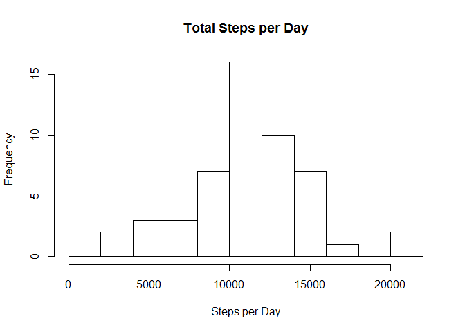

```r
sumsteps <- aggregate(Activity$steps,list(Activity$date),sum)
colnames(sumsteps)<-(c("Date","Total"))
hist(sumsteps$Total,
     breaks=10,
     main="Total Steps per Day",
     xlab="Steps per Day"
     )
```

Calculate mean and median steps per day.

```r
meansteps <- format(mean(sumsteps$Total,na.rm=TRUE),scientific=FALSE,nsmall=3)
mediansteps <- median(sumsteps$Total,na.rm=TRUE)
```

Mean steps per day is: 10766.189  
Median steps per day is: 10765

## What is the average daily activity pattern?

Take an average of steps in each 5-minute interval across days. And Plot them in a time series.

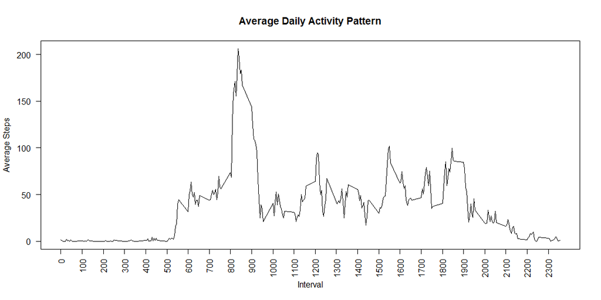

```r
avgsteps <- aggregate(Activity$steps,list(Activity$interval),mean,na.rm = TRUE)
colnames(avgsteps)<-(c("interval","Average"))

plot(avgsteps$interval,avgsteps$Average,
     type='l',
     xlab="Interval",
     ylab="Average Steps",
     main="Average Daily Activity Pattern",
     xaxt="n",
     las=2
     )

axis(side = 1, at = seq(0,2300,by=100),las=2,labels = T)
```

```r
max <- avgsteps[avgsteps$Average==max(avgsteps$Average),]
maxinterval<-max$interval
maxaverage<-max$Average
```

Interval 835 on average contains the maximum number of steps at 206.1698 steps.

## Imputing missing values

```r
count_na <- sum(!is.na(Activity$steps))
```

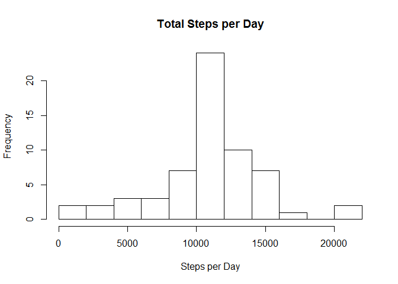

```r
#add average to each interval using merge
newActivity<-merge(Activity,avgsteps,by="interval",all.x=TRUE)
newActivity$steps[is.na(newActivity$steps)]<-ceiling(newActivity$Average[is.na(newActivity$steps)])
newActivity$Average<-NULL

sumsteps2 <- aggregate(newActivity$steps,list(newActivity$date),sum)
colnames(sumsteps2)<-(c("Date","Total"))
hist(sumsteps2$Total,
     breaks=10,
     main="Total Steps per Day",
     xlab="Steps per Day"
     )
```

Calculate mean and median steps per day.

```r
meansteps2 <- format(mean(sumsteps2$Total,na.rm=TRUE),scientific=FALSE,nsmall=3)
mediansteps2 <- format(median(sumsteps2$Total,na.rm=TRUE),scientific=FALSE)
meandiff<-as.numeric(meansteps2)-as.numeric(meansteps)
mediandiff<-as.numeric(mediansteps2)-as.numeric(mediansteps)
```

Mean steps per day is: 10784.918  
Median steps per day is: 10909

When comparing mean to the first part, there is not a significant difference (18.729) between these numbers. So there is little to no impact of imputing missing values on the mean estimate of total daily number of steps.

## Are there differences in activity patterns between weekdays and weekends?

Add a new factor variable indicating whether the date is a weekend or weekday.

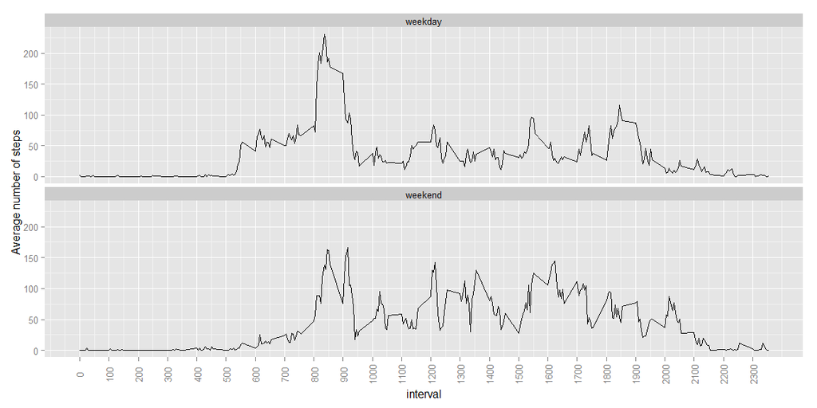

```r
newActivity$weekend <- as.factor(as.POSIXlt(newActivity$date, format='%Y-%m-%d')$wday %in% c(0, 6))
levels(newActivity$weekend) <- c("weekday","weekend")

avgsteps2 <- aggregate(newActivity$steps,list(newActivity$interval,newActivity$weekend),mean,na.rm = TRUE)
colnames(avgsteps2)<-(c("interval","weekpart","Average"))

library(ggplot2)
g<-ggplot(avgsteps2,aes(interval,Average))
g + geom_line() + facet_wrap(~ weekpart,nrow=2) +
  scale_x_continuous(breaks=seq(0,2300,by=100)) +
  theme(axis.text.x = element_text(angle = 90, vjust = .5)) +
  labs(y="Average number of steps")
```

Activity on the weekend appears to start later in the morning, but the pattern throughout the day is higher overall than on weekdays.